# Text Analysis for Tweets about Unemployment during Pandemic

2022-04-13

# Overview

# Word Clouds

**Word Clouds using Unemployment Tweets in 2019, 2020, 2021 respectively.**

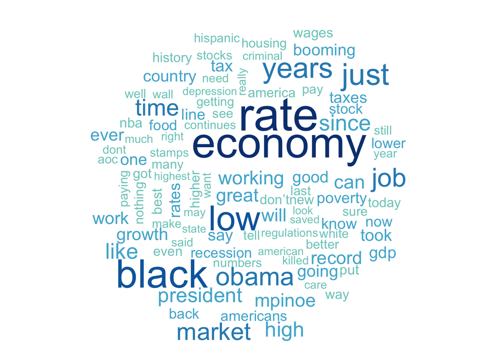

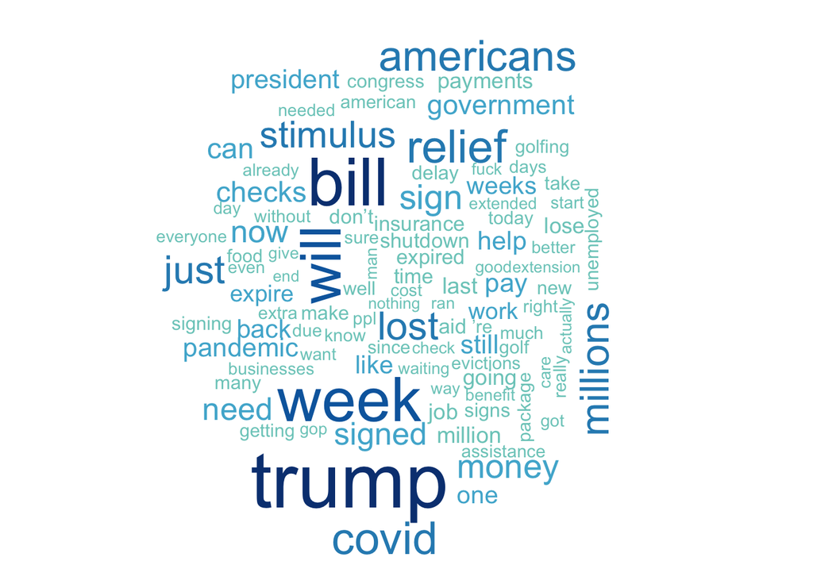

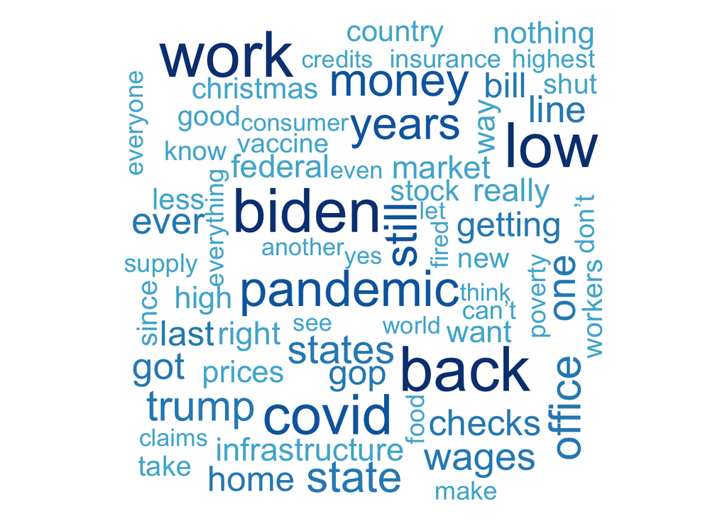

# Word Frequency Visualization

Most freuqent terms in unemployment tweets in 2019 were “rate”, “economy”, “lowest”, and “black”. This is the result from the pre-covid time, so we could observe that even during the time prior to the pandemic, Americans were not very content with the unemployment situation in the U.S.  
The most frequent terms in 2020 and 2021 were “bill”, “covid”, “relief”, “job”, “low”, “biden”, “back”, and “americans”. From these selected top words, it seems that people are looking for change and relief.

**Word Frequency Visualizations in 2019, 2020, 2021 respectively.**

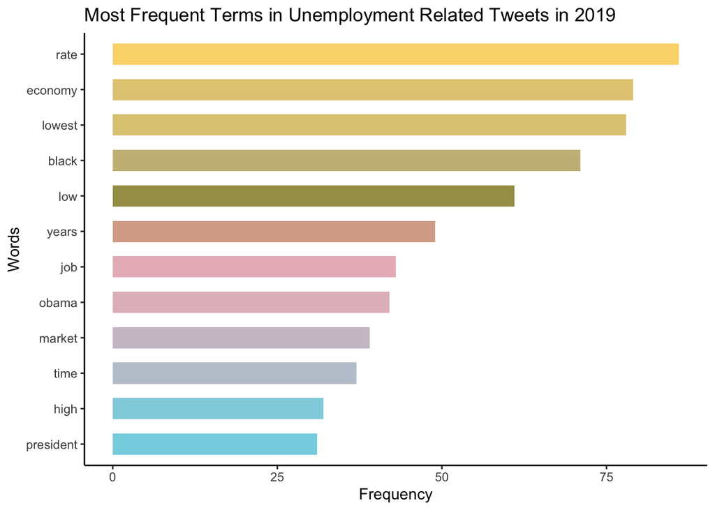

[figure not shown]

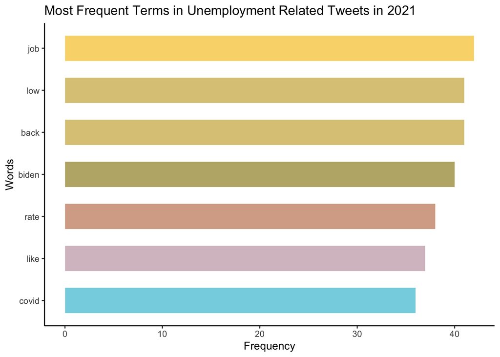

# Sentiment Analysis

We performed sentiment analysis using the Bing lexicon. It seems that in 2019, the proportion of positive and negative words appeared are equally distributed. Although the number of counts of negative words appeared are somewhat greater than that of positive words, the it seems that there were more variety of positive sentiments appeared in 2019 tweets, contributing to the total counts of positive words in 2019 tweets.  
During the pandemic, more words with negative sentiment appeared in unemployment related tweets, which is evident in the below graph. As the pandemic started and the economy went down, the unemployment tweets had about twice more negative words.

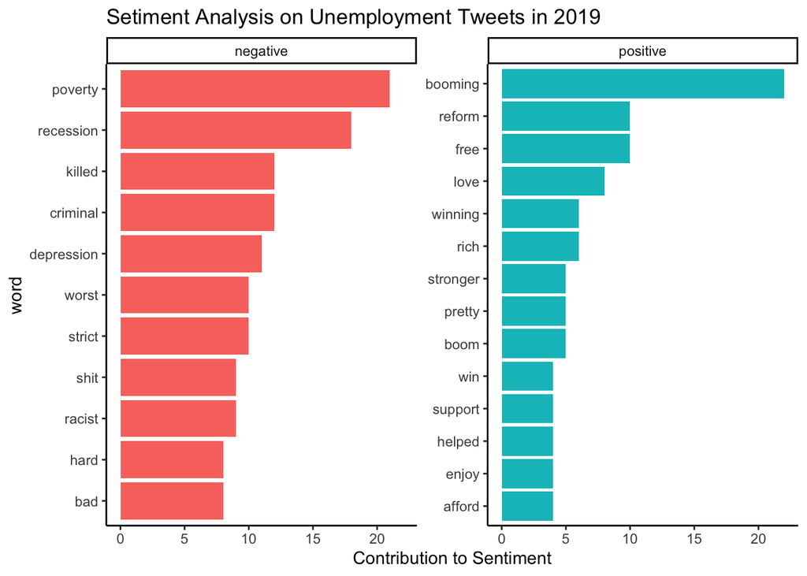

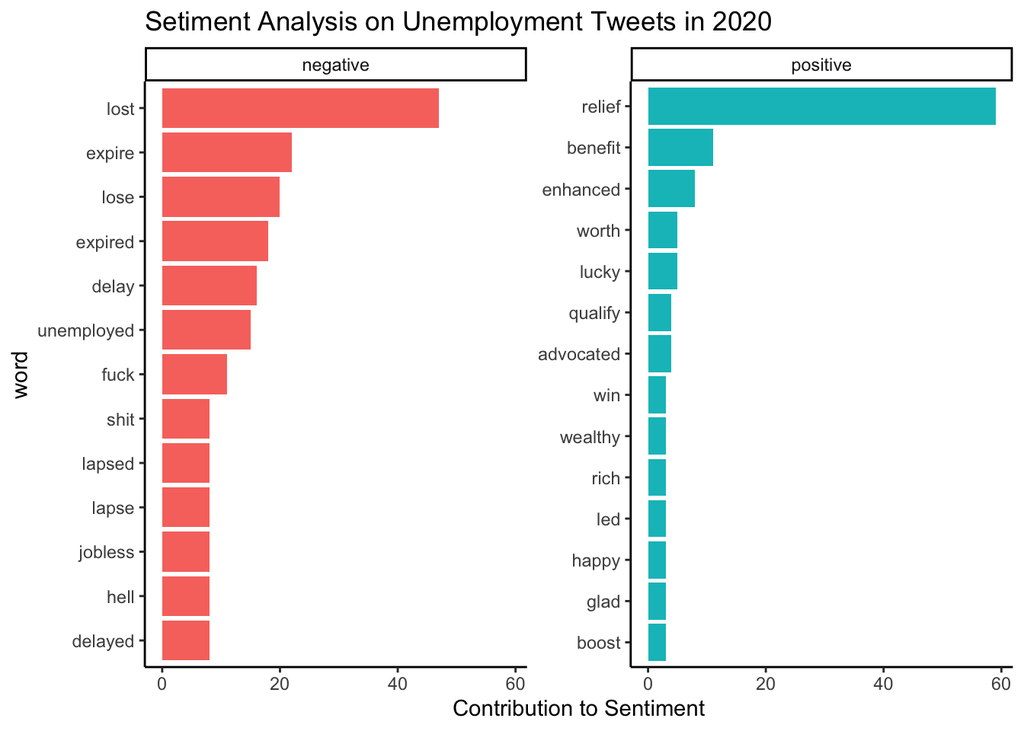

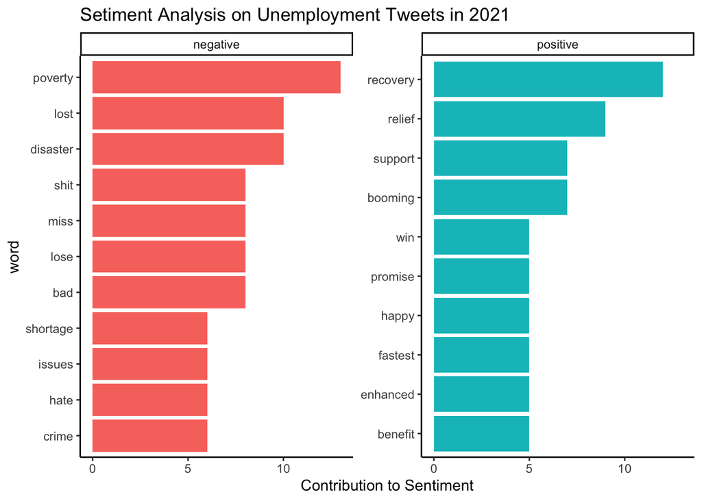

# Most Frequent Positive and Negative Words in Tweets

From the word clouds below, it seems that the key words in each year seem to be “booming”, “relief”, and “recovery”. From these keywords, we could assume the message people had about the employment situation during the time. In 2019, people were concerned on economic reform and how to improve the employment rate and decrease poverty.  
Once the pandemic started, in 2020, people were concerned about (job) loss, as the words “lost”, “lapsed”, “losing”, “lose” occured frequently. In 2021, from the result, we could suppose that the economic situation is getting better compared to the prior year, as more positive words appeared, such as “recovery”, “releif”, “support”, “enhanced”, “happy”, “easy”, and “promise”.

**Sentiment Analysis using Word Cloud for 2019, 2020, 2021 respectively.**

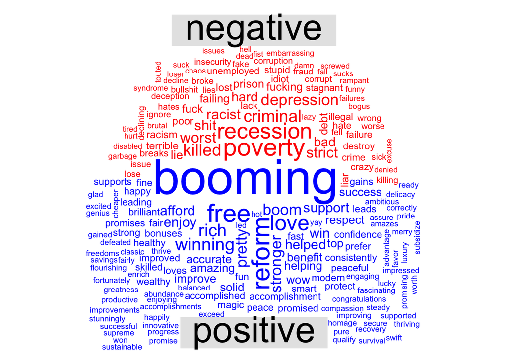

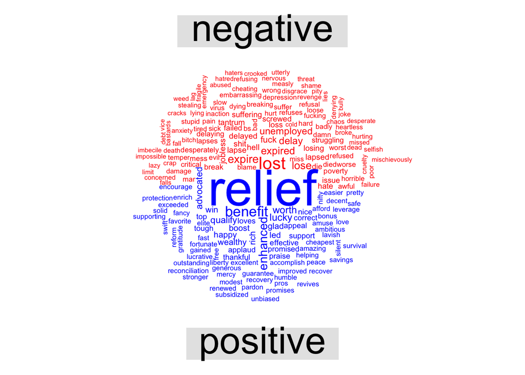

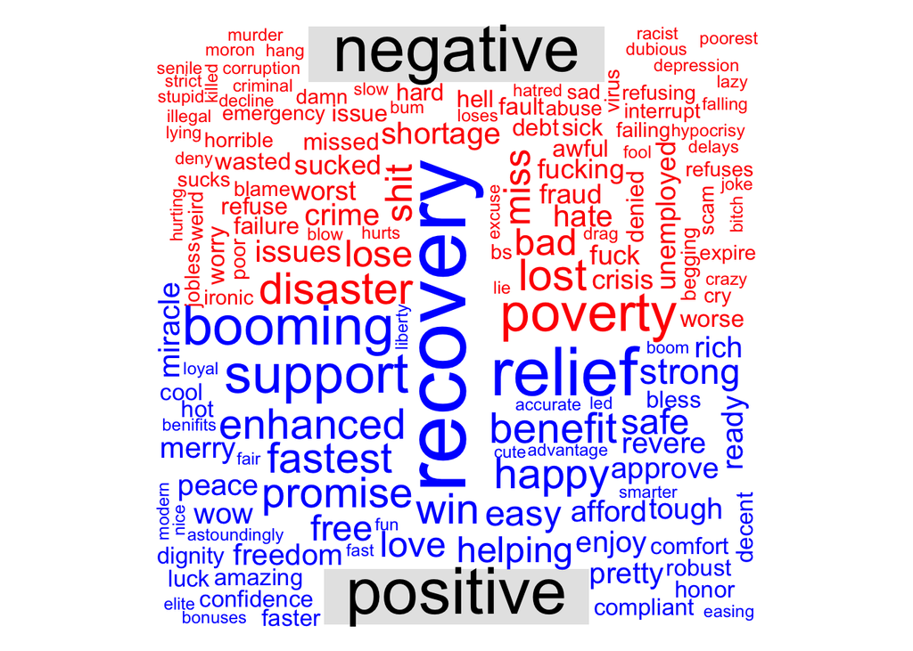